# lab-02

Author

Katie Zhao

### **Packages**

```r
library(tidyverse)
```

### **Read in the data**

```r
met <- read.csv("met_all.gz")
```

### **Check the dimensions, headers, footers**

```r
dim(met)
```

```
[1] 2377343      30
```

There are 2377343 rows and 30 columns in this dataset.

### **Take a look at all the variables (hint: use the str function)**

```r
str(met)
```

```
'data.frame':   2377343 obs. of  30 variables:
 $ USAFID           : int  690150 690150 690150 690150 690150 690150 690150 690150 690150 690150 ...
 $ WBAN             : int  93121 93121 93121 93121 93121 93121 93121 93121 93121 93121 ...
 $ year             : int  2019 2019 2019 2019 2019 2019 2019 2019 2019 2019 ...
 $ month            : int  8 8 8 8 8 8 8 8 8 8 ...
 $ day              : int  1 1 1 1 1 1 1 1 1 1 ...
 $ hour             : int  0 1 2 3 4 5 6 7 8 9 ...
 $ min              : int  56 56 56 56 56 56 56 56 56 56 ...
 $ lat              : num  34.3 34.3 34.3 34.3 34.3 34.3 34.3 34.3 34.3 34.3 ...
 $ lon              : num  -116 -116 -116 -116 -116 ...
 $ elev             : int  696 696 696 696 696 696 696 696 696 696 ...
 $ wind.dir         : int  220 230 230 210 120 NA 320 10 320 350 ...
 $ wind.dir.qc      : chr  "5" "5" "5" "5" ...
 $ wind.type.code   : chr  "N" "N" "N" "N" ...
 $ wind.sp          : num  5.7 8.2 6.7 5.1 2.1 0 1.5 2.1 2.6 1.5 ...
```

[output cut: 16 more lines]

### **Take a closer look at the key variables (year, day, hour, temp, elev, wind.sp). Hint: use table and/or summary).**

```r
table(met$year)
```

```
   2019
2377343
```

```r
table(met$day)
```

```
    1     2     3     4     5     6     7     8     9    10    11    12    13
75975 75923 76915 76594 76332 76734 77677 77766 75366 75450 76187 75052 76906
   14    15    16    17    18    19    20    21    22    23    24    25    26
77852 76217 78015 78219 79191 76709 75527 75786 78312 77413 76965 76806 79114
   27    28    29    30    31
79789 77059 71712 74931 74849
```

```r
table(met$hour)
```

```
     0      1      2      3      4      5      6      7      8      9     10
 99434  93482  93770  96703 110504 112128 106235 101985 100310 102915 101880
    11     12     13     14     15     16     17     18     19     20     21
100470 103605  97004  96507  97635  94942  94184 100179  94604  94928  96070
    22     23
 94046  93823
```

```r
summary(met$temp)
```

```
   Min. 1st Qu.  Median    Mean 3rd Qu.    Max.    NA's
 -40.00   19.60   23.50   23.59   27.80   56.00   60089
```

```r
summary(met$elev)
```

```
   Min. 1st Qu.  Median    Mean 3rd Qu.    Max.
  -13.0   101.0   252.0   415.8   400.0  9999.0
```

```r
summary(met$wind.sp)
```

```
   Min. 1st Qu.  Median    Mean 3rd Qu.    Max.    NA's
   0.00    0.00    2.10    2.46    3.60   36.00   79693
```

Replace elevations with 9999 as NA.

```r
met <- met %>%
  mutate(elev1 = ifelse(elev == 9999, NA, elev))
```

At what elevation is the highest weather station?

```r
summary(met$elev1)
```

```
   Min. 1st Qu.  Median    Mean 3rd Qu.    Max.    NA's
    -13     101     252     413     400    4113     710
```

4113 meters

We also have the issue of the minimum temperature being -40C, so we should remove those observations. Also, remove the NA temperature points.

```r
met1 <- met %>%
  filter(temp != -40) %>%
  filter(!is.na(temp))

summary(met1$temp)
```

```
   Min. 1st Qu.  Median    Mean 3rd Qu.    Max.
 -17.20   19.60   23.50   23.59   27.80   56.00
```

The new lowest temperature is -17.20 degrees Celsius.

### **Check the data against an external data source.**

```r
summary(met1$elev1)
```

```
   Min. 1st Qu.  Median    Mean 3rd Qu.    Max.    NA's
  -13.0   101.0   252.0   414.3   400.0  4113.0     182
```

The range of elevations is now -13 meters to 4113 meters. Given that the lowest elevation in the United States is -85.3 meters (Death Valley California) and the highest is 6190.5 meters (Denali Borough, Alaska), the range seen in the dataset does make sense.

```r
met1 %>%
  filter(temp == -17.20) %>%
  select(lat, lon)
```

```
     lat    lon
1 38.767 -104.3
2 38.767 -104.3
3 38.767 -104.3
4 38.767 -104.3
5 38.767 -104.3
6 38.767 -104.3
```

The latitude and longitude of this suspicious -17.2C temperature value is (38.767, -104.3), which is located near El Paso County, Colorado. Thus, it is unlikely that during the month of August, it had a recorded temperature of -17.2C.

```r
met1 <- met1 %>%
  mutate(temp = ifelse(temp == -17.20, NA, temp))
summary(met1$temp)
```

```
   Min. 1st Qu.  Median    Mean 3rd Qu.    Max.    NA's
 -17.00   19.60   23.50   23.59   27.80   56.00       6
```

### **Calculate summary statistics**

Remember to keep the initial question in mind. We want to pick out the weather station with maximum elevation and examine its windspeed and temperature.

```r
met_eda <- met1[met1$elev1 == 4113, c("temp", "wind.sp", "hour", "day")]
```

Some ideas: select the weather station with maximum elevation; within this station, look at the correlation between temperature and wind speed; look at the correlation between each of temperature and wind speed with each of hour and day.

```r
cor(met_eda$temp, met_eda$wind.sp, use = "complete.obs")
```

```
[1] -0.09373843
```

```r
cor(met_eda$temp, met_eda$hour, use = "complete.obs")
```

```
[1] 0.4397261
```

```r
cor(met_eda$temp, met_eda$day, use = "complete.obs")
```

```
[1] -0.003857766
```

```r
cor(met_eda$wind.sp, met_eda$hour, use = "complete.obs")
```

```
[1] 0.08807315
```

```r
cor(met_eda$wind.sp, met_eda$day, use = "complete.obs")
```

```
[1] 0.3643079
```

```r
cor(met_eda, use = "complete.obs")
```

```
                temp     wind.sp         hour          day
temp     1.000000000 -0.09373843  0.435680110 -0.006130763
wind.sp -0.093738431  1.00000000  0.088073152  0.364307915
hour     0.435680110  0.08807315  1.000000000 -0.004546462
day     -0.006130763  0.36430791 -0.004546462  1.000000000
```

The variables with the highest correlation are between temperature and hour (0.4397261) as well as wind speed and day (0.3643079).

### **Exploratory graphs**

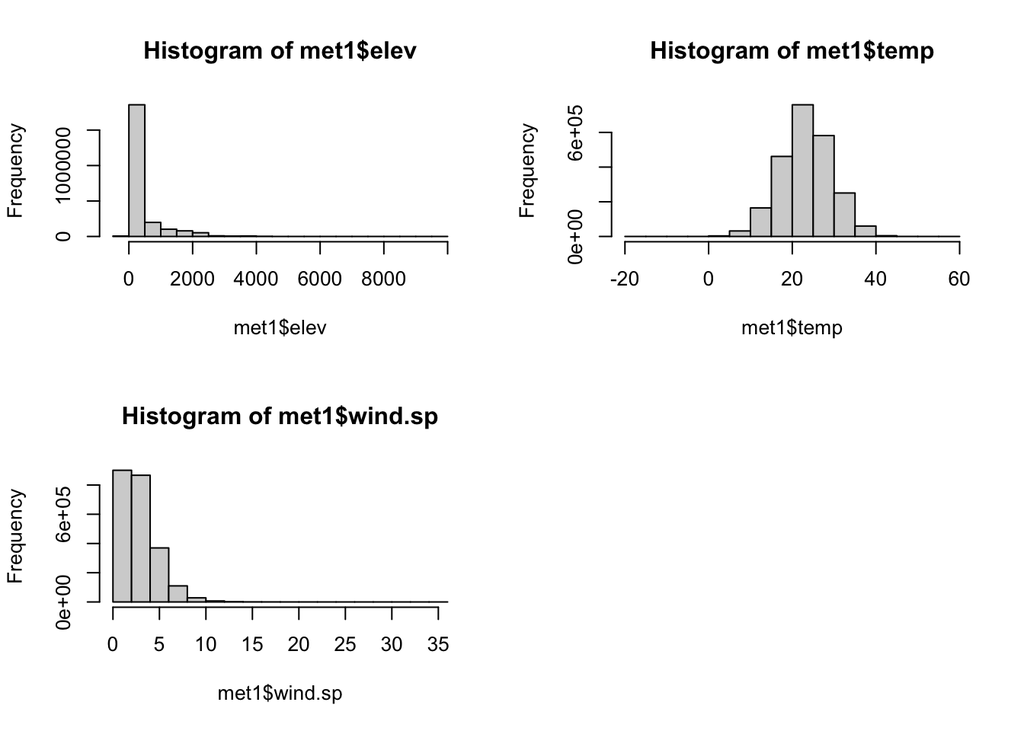

```r
par(mfrow = c(2,2))
hist(met1$elev)
hist(met1$temp)
hist(met1$wind.sp)
```

```r
library(leaflet)

elev <- met1[met1$elev1 == 4113, ]

leaflet(elev) %>%
  addProviderTiles('OpenStreetMap') %>%
  addCircles(lat=~lat,lng=~lon, opacity=1, fillOpacity=1, radius=100)
```

[interactive chart not shown]

Look at the time series of temperature and wind speed at this location. For this we will need to create a date-time variable for the x-axis.

```r
library(lubridate)
elev$date <- with(elev, ymd_h(paste(year, month, day, hour, sep= ' ')))
summary(elev$date)
```

```
                      Min.                    1st Qu.
"2019-08-01 00:00:00.0000" "2019-08-08 11:00:00.0000"
                    Median                       Mean
"2019-08-16 22:00:00.0000" "2019-08-16 14:09:56.8823"
                   3rd Qu.                       Max.
"2019-08-24 11:00:00.0000" "2019-08-31 22:00:00.0000"
                      NA's
                     "182"
```

```r
elev <- elev[order(elev$date), ]
head(elev)
```

```
       USAFID WBAN year month day hour min  lat      lon elev wind.dir
216295 720385  419 2019     8   1    0  36 39.8 -105.766 4113      170
216296 720385  419 2019     8   1    0  54 39.8 -105.766 4113      100
216297 720385  419 2019     8   1    1  12 39.8 -105.766 4113       90
216298 720385  419 2019     8   1    1  35 39.8 -105.766 4113      110
216299 720385  419 2019     8   1    1  53 39.8 -105.766 4113      120
216300 720385  419 2019     8   1    2  12 39.8 -105.766 4113      120
       wind.dir.qc wind.type.code wind.sp wind.sp.qc ceiling.ht ceiling.ht.qc
216295           5              N     8.8          5       1372             5
216296           5              N     2.6          5       1372             5
216297           5              N     3.1          5       1981             5
216298           5              N     4.1          5       2134             5
216299           5              N     4.6          5       2134             5
216300           5              N     6.2          5      22000             5
       ceiling.ht.method sky.cond vis.dist vis.dist.qc vis.var vis.var.qc temp
```

[output cut: 20 more lines]

Given the date-time variable, plot the time series of temperature and also wind speed.

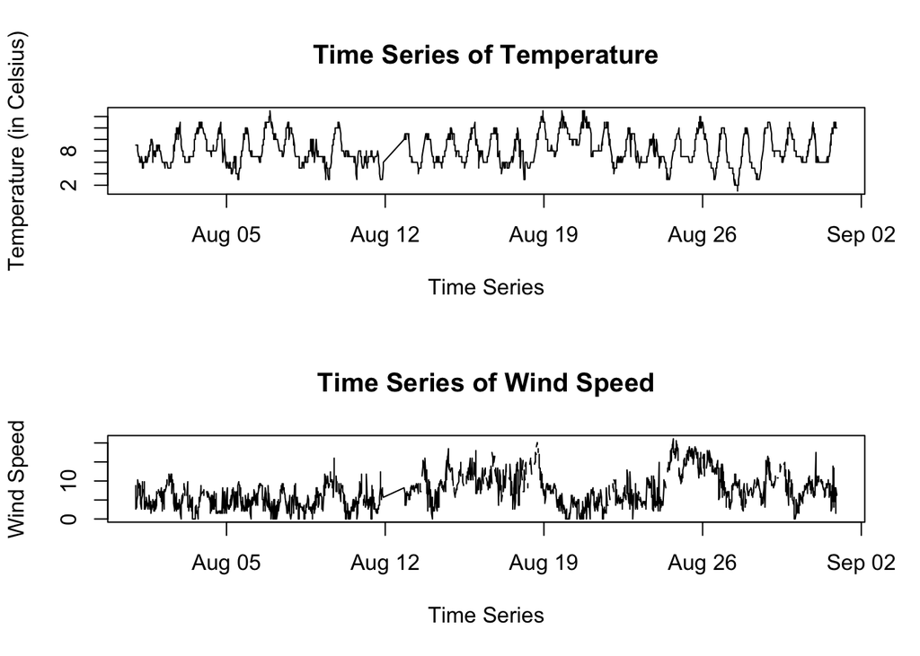

```r
par(mfrow = c(2,1))

plot(elev$date, elev$temp,
     xlab = "Time Series",
     ylab = "Temperature (in Celsius)",
     main = "Time Series of Temperature",
     type = "l")

plot(elev$date, elev$wind.sp,
     xlab = "Time Series",
     ylab = "Wind Speed",
     main = "Time Series of Wind Speed",
     type = "l")
```

For the time series of temperature, there is a strong cyclical pattern of the temperature increasing and decreasing within the same range (~2C - 14C), roughly on what appeared to have a daily basis (which makes sense, given that in a given day the temperature tends to rise/fall naturally).

For the time series of wind speed, there also seems to be a cyclical nature of the wind speeds rising and fall within the course of a day (similar to temperature). However, during the latter half of the month, the “overall” trend of wind speed experienced a rise between August 12-19, then a fall between August 18-20, and then a rise again between August 20-28.

### **Ask questions**

Question: Is there a relationship between latitude/longtitude and temperature (looking at the US “horizontally”)?

Using Day 8, Hour 12 Observations

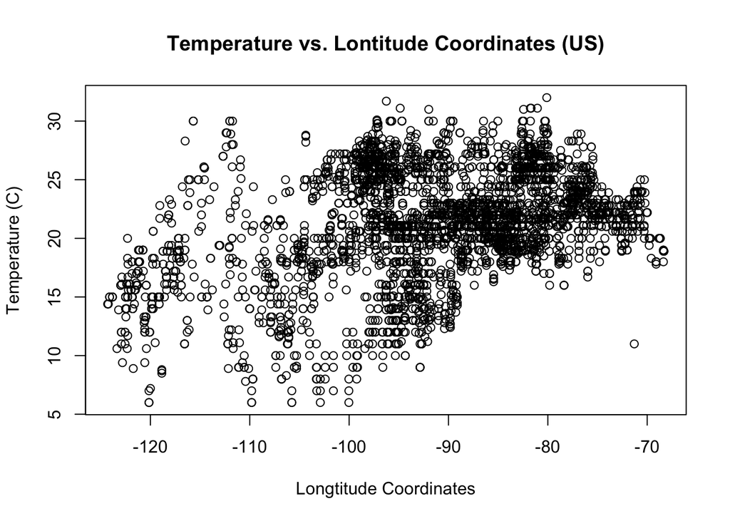

```r
met_q <- met %>%
  filter(day == 8,
         hour == 12)

plot(met_q$lon, met_q$temp,
     xlab = "Longtitude Coordinates", ylab = "Temperature (C)",
     main = "Temperature vs. Lontitude Coordinates (US)")
```

```r
cor(met_q$lon, met_q$temp, use = "complete.obs")
```

```
[1] 0.3770869
```

-120 degrees corresponds to the West side of the country, while -70 corresponds to the East. Though the correlation is relatively low (0.3770869), there’s a trend that stations on the East reported higher temperatures than those on the West (on this specific day in August).

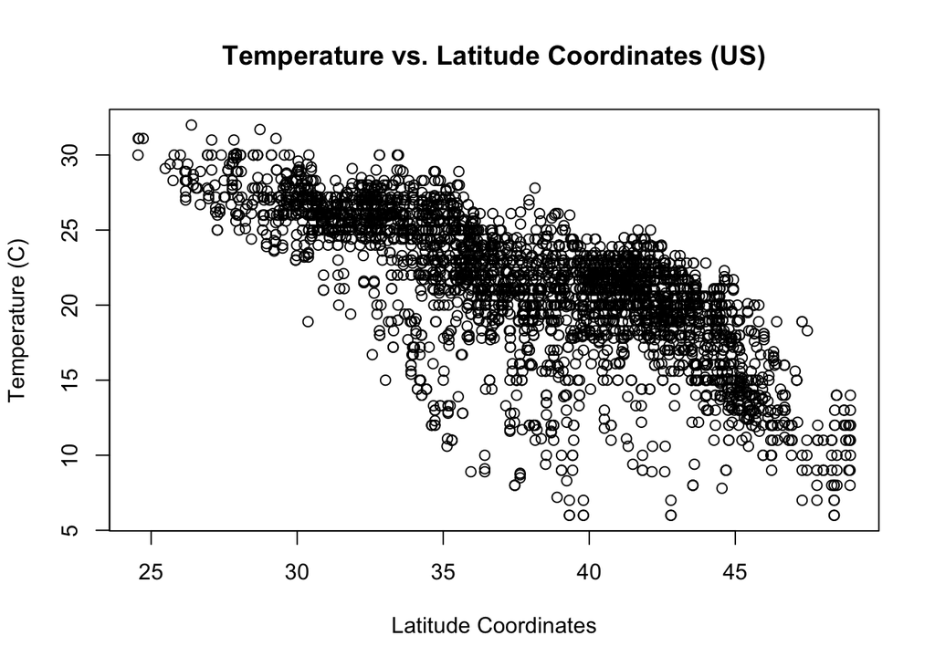

```r
plot(met_q$lat, met_q$temp,
     xlab = "Latitude Coordinates", ylab = "Temperature (C)",
     main = "Temperature vs. Latitude Coordinates (US)")
```

```r
cor(met_q$lat, met_q$temp, use = "complete.obs")
```

```
[1] -0.7190146
```

25 degrees corresponds to the South part of the country, while 45 corresponds to the North. Here, a clearer trend (|correlation| = 0.7190146) is seen where as latitude increases (move up north), temperature decreases.